# Lab1

Viktoriia Tsykun

17 02 2022

This assignment is based on materials from Coursera course [Exploratory Data Analysis](https://www.coursera.org/learn/exploratory-data-analysis/home/welcome)

## Introduction

Fine particulate matter (PM2.5) is an ambient air pollutant for which there is strong evidence that it is harmful to human health. In the United States, the Environmental Protection Agency (EPA) is tasked with setting national ambient air quality standards for fine PM and for tracking the emissions of this pollutant into the atmosphere. Approximatly every 3 years, the EPA releases its database on emissions of PM2.5. This database is known as the National Emissions Inventory (NEI). You can read more information about the NEI at the EPA National Emissions Inventory web site.

For each year and for each type of PM source, the NEI records how many tons of PM2.5 were emitted from that source over the course of the entire year. The data that you will use for this assignment are for 1999, 2002, 2005, and 2008.

## Data

The data for this assignment could be downloaded by the [link](https://www.dropbox.com/s/fey54ngk8g4z6rr/exdata_data_NEI_data.zip?dl=0):

The zip file contains two files:

**PM2.5 Emissions Data** (`summarySCC_PM25.rds`): This file contains a data frame with all of the PM2.5 emissions data for 1999, 2002, 2005, and 2008. For each year, the table contains number of tons of PM2.5 emitted from a specific type of source for the entire year.

- **fips**: A five-digit number (represented as a string) indicating the U.S. county
- **SCC**: The name of the source as indicated by a digit string (see source code classification table)
- **Pollutant**: A string indicating the pollutant
- **Emissions**: Amount of PM2.5 emitted, in tons
- **type**: The type of source (point, non-point, on-road, or non-road)
- **year**: The year of emissions recorded

**Source Classification Code Table** (`Source_Classification_Code.rds`): This table provides a mapping from the SCC digit strings in the Emissions table to the actual name of the PM2.5 source. The sources are categorized in a few different ways from more general to more specific and you may choose to explore whatever categories you think are most useful. For example, source “10100101” is known as “Ext Comb /Electric Gen /Anthracite Coal /Pulverized Coal”.

You can read each of the two files using the `readRDS()` function in R. For example, reading in each file can be done with the following code:

```
NEI <- readRDS("summarySCC_PM25.rds")
SCC <- readRDS("Source_Classification_Code.rds")
```

## Questions

You must address the following questions and tasks in your exploratory analysis. For each question/task you will need to make a single **bar** plot. You can use any plotting system in R to make your plot.

1. Have total emissions from PM2.5 decreased in the United States from 1999 to 2008? Make a plot showing the **total** PM2.5 emission from all sources for each of the years 1999, 2002, 2005, and 2008.
2. Have total emissions from PM2.5 decreased in the **Baltimore City**, Maryland (`fips == "24510"`) from 1999 to 2008?
3. Of the four types of sources indicated by the `type` (point, nonpoint, onroad, nonroad) variable, which of these four sources have seen decreases in emissions from 1999–2008 for **Baltimore City**? Which have seen increases in emissions from 1999–2008?
4. Across the United States, how have emissions from coal combustion-related sources changed from 1999–2008?
5. How have emissions from motor vehicle sources changed from 1999–2008 in **Baltimore City** (EI.Sector starts from “Mobile”)?
6. Compare emissions from motor vehicle sources in Baltimore City with emissions from motor vehicle sources in **Los Angeles County**, California (`fips == "06037"`). Which city has seen greater changes over time in motor vehicle emissions?

## Answers

Спочатку прочитаємо кожен з файлів

```r
NEI <- readRDS("./data/summarySCC_PM25.rds")
SCC <- readRDS("./data/Source_Classification_Code.rds")
library(ggplot2)
```

1. Have total emissions from PM2.5 decreased in the United States from 1999 to 2008? Make a plot showing the **total** PM2.5 emission from all sources for each of the years 1999, 2002, 2005, and 2008.

Для отримання інформації потрібно агрегувати дані використовуючи функцію aggregate:

```r
total_emissions_per_year <- aggregate(NEI$Emissions, list(NEI$year), sum)
colnames(total_emissions_per_year) <- c("Year", "Total")
total_emissions_per_year
```

```
##   Year   Total
## 1 1999 7332967
## 2 2002 5635780
## 3 2005 5454703
## 4 2008 3464206
```

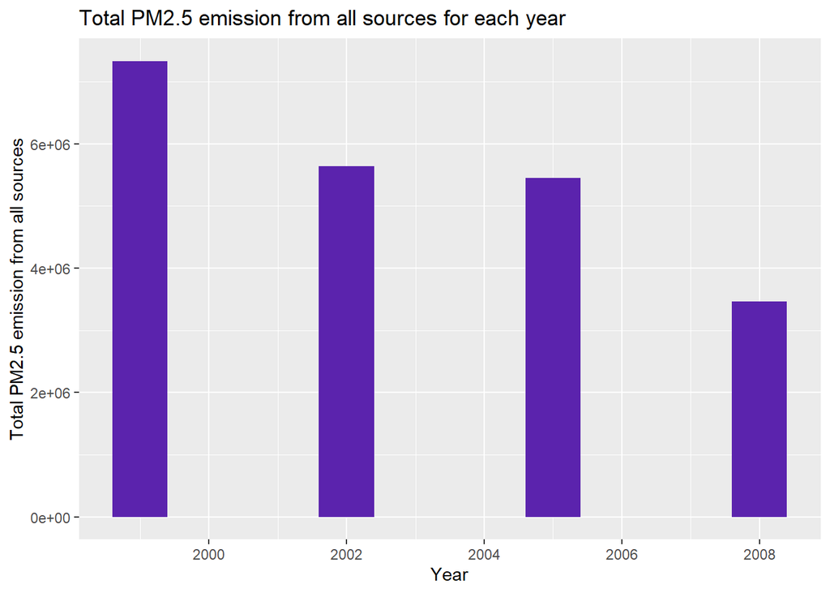

```r
ggplot(total_emissions_per_year, aes(x=Year,y=Total)) + labs(x="Year", y="Total PM2.5 emission from all sources", title="Total PM2.5 emission from all sources for each year") + geom_bar(width=0.8, stat="identity", fill="#5b23ad")
```

**Так, загальні викиди зменшилися з 1999-го року по 2008-ий**

2. Have total emissions from PM2.5 decreased in the **Baltimore City**, Maryland (`fips == "24510"`) from 1999 to 2008?

```r
total_emissions_per_year_balt <- aggregate(NEI$Emissions[NEI$fips=="24510"], list(NEI$year[NEI$fips=="24510"]), sum)
colnames(total_emissions_per_year_balt) <- c("Year", "Total")
total_emissions_per_year_balt
```

```
##   Year    Total
## 1 1999 3274.180
## 2 2002 2453.916
## 3 2005 3091.354
## 4 2008 1862.282
```

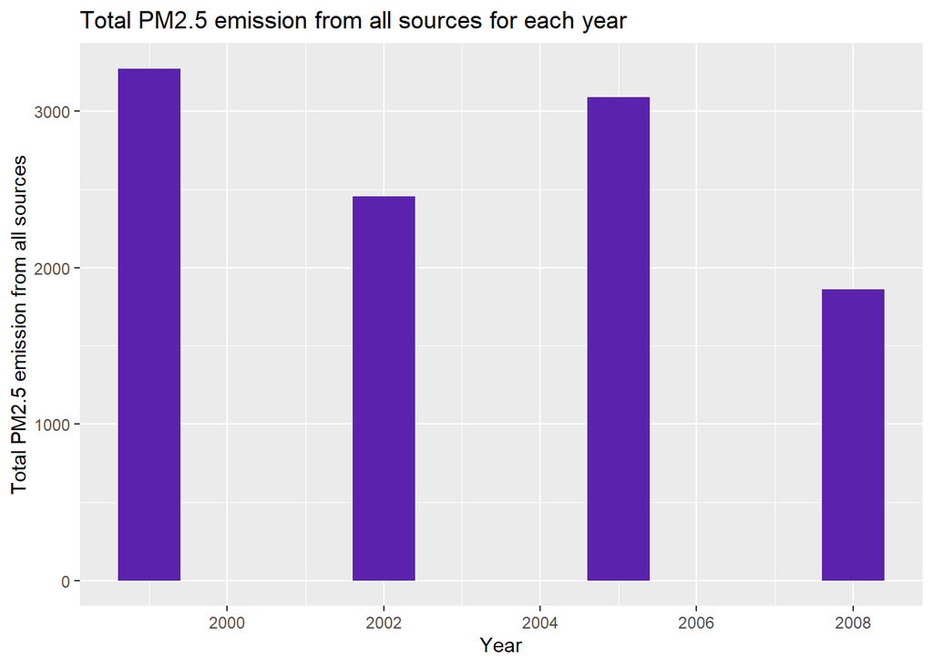

```r
ggplot(total_emissions_per_year_balt, aes(x=Year,y=Total)) + labs(x="Year", y="Total PM2.5 emission from all sources", title="Total PM2.5 emission from all sources for each year") + geom_bar(width=0.8, stat="identity", fill="#5b23ad")
```

**Можна спостерігати деяку “хвилю”, проте загалом загальні викиди в Балтиморі зменшилися з 1999 по 2008**

3. Of the four types of sources indicated by the `type` (point, nonpoint, onroad, nonroad) variable, which of these four sources have seen decreases in emissions from 1999–2008 for **Baltimore City**? Which have seen increases in emissions from 1999–2008?

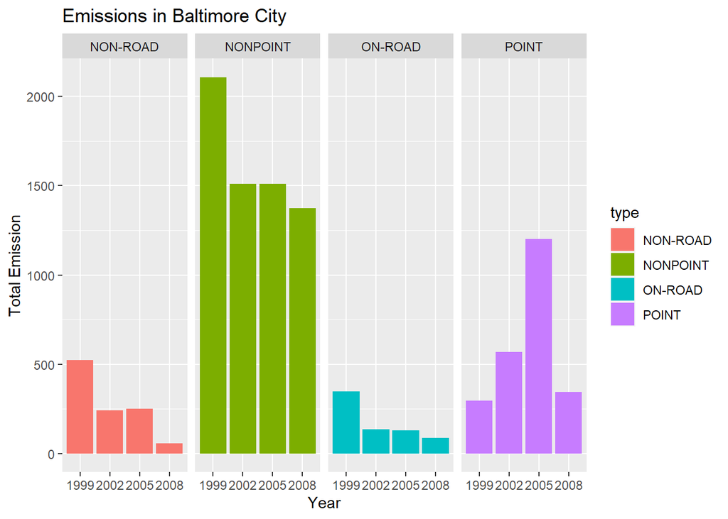

```r
NEI_Balt <- NEI[NEI$fips=="24510",]
ggplot(NEI_Balt, aes(factor(year), Emissions, fill=type)) + geom_bar(stat="identity") + facet_grid(.~type) + labs(x="Year", y="Total Emission", title="Emissions in Baltimore City")
```

**Загалом спостерігається зменшення загальних викидів для трьох типів джерел (nonroad, nonpoint, onroad). Для четвертого типу point спостерігається значне збільшення викидів у 2005 році, а у 2008 - значне зменшення, проте рівень викидів все одно більше ніж за 1999 рік**

4. Across the United States, how have emissions from coal combustion-related sources changed from 1999–2008?

```r
combustion <- grepl("comb",  SCC$SCC.Level.One, ignore.case=TRUE)
coal <- grepl("coal", SCC$SCC.Level.Four, ignore.case=TRUE)
SCC_coal_combustion <- SCC[(combustion & coal),]$SCC
NEI_coal_combustion <- NEI[NEI$SCC %in% SCC_coal_combustion,]
head(NEI_coal_combustion)
```

```
##        fips      SCC Pollutant Emissions  type year
## 9979  09011 10100217  PM25-PRI   479.907 POINT 1999
## 19504 23005 10200202  PM25-PRI     0.119 POINT 1999
## 22888 23009 10200219  PM25-PRI     3.419 POINT 1999
## 28873 23017 10200219  PM25-PRI    11.242 POINT 1999
## 44907 25005 10100202  PM25-PRI  1012.027 POINT 1999
## 44911 25005 10100212  PM25-PRI  1050.520 POINT 1999
```

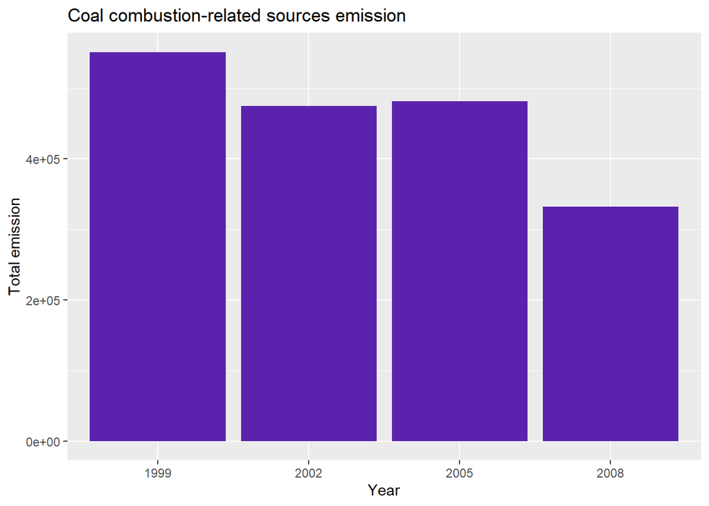

```r
ggplot(NEI_coal_combustion, aes(factor(year), Emissions)) + geom_bar(stat="identity", fill="#5b23ad") + labs(x="Year", y="Total emission", title="Coal combustion-related sources emission")
```

**Спостерігається зменшення викидів**

5. How have emissions from motor vehicle sources changed from 1999–2008 in **Baltimore City** (EI.Sector starts from “Mobile”)?

```r
vehicle <- grepl("vehicle",  SCC$SCC.Level.Two, ignore.case=TRUE)
SCC_vehicle <- SCC[vehicle,]$SCC
NEI_vehicle <- NEI[NEI$SCC %in% SCC_vehicle,]
NEI_vehicle_balt <- NEI_vehicle[NEI_vehicle$fips == 24510,]
head(NEI_vehicle_balt)
```

```
##         fips        SCC Pollutant Emissions    type year
## 114470 24510 220100123B  PM25-PRI      7.38 ON-ROAD 1999
## 114472 24510 220100123T  PM25-PRI      2.78 ON-ROAD 1999
## 114477 24510 220100123X  PM25-PRI     11.76 ON-ROAD 1999
## 114479 24510 220100125B  PM25-PRI      3.50 ON-ROAD 1999
## 114481 24510 220100125T  PM25-PRI      1.32 ON-ROAD 1999
## 114486 24510 220100125X  PM25-PRI      5.58 ON-ROAD 1999
```

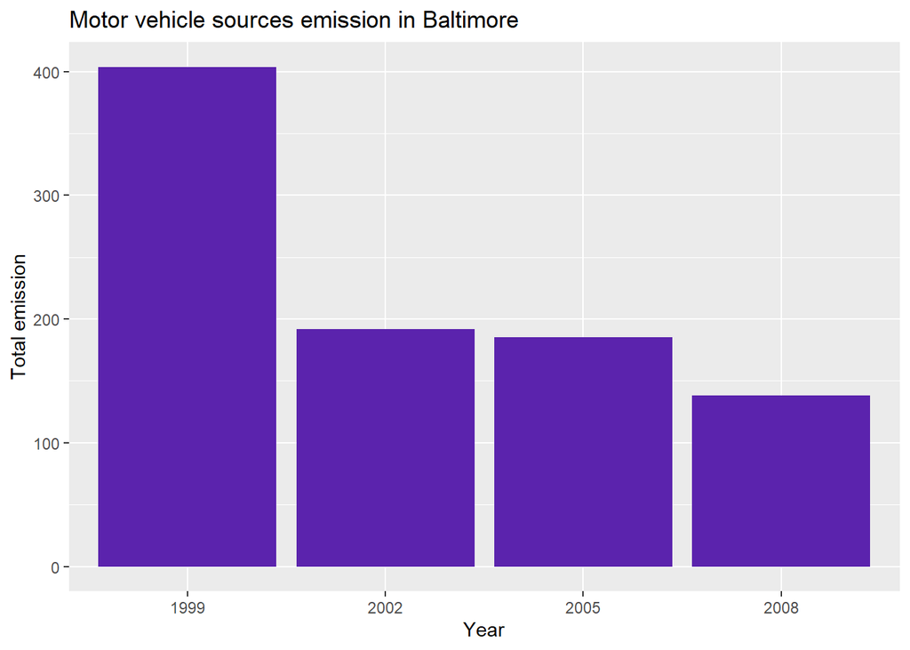

```r
ggplot(NEI_vehicle_balt, aes(factor(year), Emissions)) + geom_bar(stat="identity", fill="#5b23ad") + labs(x="Year", y="Total emission", title="Motor vehicle sources emission in Baltimore")
```

**Спостерігається зменшення викидів**

6. Compare emissions from motor vehicle sources in Baltimore City with emissions from motor vehicle sources in **Los Angeles County**, California (`fips == "06037"`). Which city has seen greater changes over time in motor vehicle emissions?

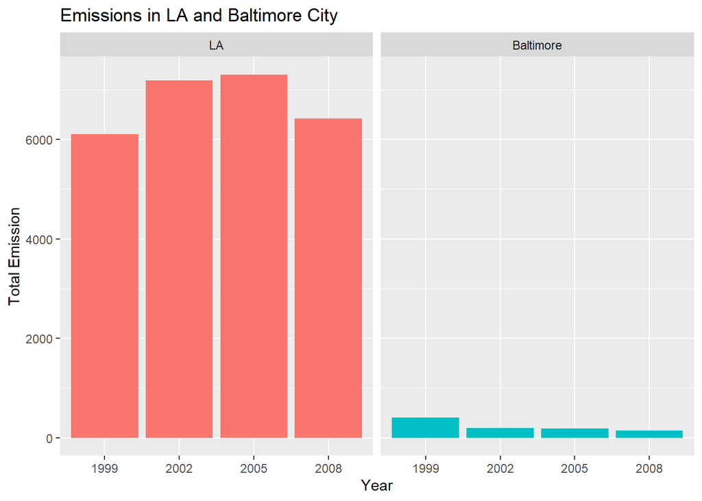

```r
NEI_vehicle_la <- NEI_vehicle[NEI_vehicle$fips == "06037",]
NEI_vehicle_balt_la <- rbind(NEI_vehicle_balt, NEI_vehicle_la)

cities_names <- c(`06037` = "LA", `24510` = "Baltimore")

ggplot(NEI_vehicle_balt_la, aes(factor(year), Emissions, fill=fips)) + geom_bar(stat="identity") + guides(fill="none") + facet_grid(.~fips, labeller=as_labeller(cities_names)) + labs(x="Year", y="Total Emission", title="Emissions in LA and Baltimore City")
```